# IS 6812 - Group 5 Combined Modeling Submission

Andrew Walton, Michael Tom, Ian Donaldson, and Louis Ackumey

2023-11-03

# Introduction

## Project Goal

In this exploration, we aim to delve into Home Credit’s dataset, with a focus on understanding crucial features and identifying any necessary data cleaning processes. Our ultimate objective is to create a predictive model capable of determining whether a customer will successfully repay a loan or default. We want the model that we create to outperform a majority class classifier on prediction of our target variable (default).

## Business Problem

Home Credit operates in rapidly growing and developing markets where many consumers lack traditional credit scores common in more developed economies. Many of their customers have little to no credit history. To maintain acceptable levels of loan losses while expanding its lending portfolio, Home Credit requires a predictive model that leverages alternative data sources, such as transaction information and telecommunications data, to assess the likelihood of customer loan default.

## Analytics Problem

Our analytics problem centers around building a machine-learning classification model that predicts loan defaults. Historical data from past customers in the training data set, including transaction and telco information, will serve as input features. This model will then be used to predict the probability of default for previously unseen customers in the test data set with effectiveness measured by AUC-ROC.

## Purpose of Notebook

This notebook will serve as a guide for the data preparation, modeling processes, and modeling selection.

## Questions About Data

As part of our exploration, answers to the following questions will be sought: - Can the features of data be categorized into a set of general topics? - How many missing values are there in each column?  
- How many total missing values are there? - What will we do with variables with missing data? - Is the target variable (loan default) balanced or unbalanced, and what is the percentage distribution?  
- Will we need to do any transformation on the data to make them work for our models? - What accuracy can be achieved with a simple majority class classifier?  
- What are key issues with the unprocessed data?  
- Are there any strong predictors that should be included in our predictive model?  
- Are there any outliers in the data, and how should they be handled?  
- Do the data values align with expectations, and are there any erroneous values requiring cleaning?  
- Are there any columns with near-zero or zero variance?  
- Will data transformation be necessary to prepare it for modeling? - What is the current % of customers defaulting loans? - Are there any indications of errors in the data? If so how will these be addressed? - Are there any variables that maybe helpful, but might be discriminatory if used?

To start, we will load all of the libraries that we will need to run our various models

```r
library(tidyverse)
library(skimr)
library(janitor)
library(caret)
library(tictoc)
library(car)
```

```r
library(corrplot)
library(glmnet)
library(lares)
library(e1071)
library(ROCR)
library(missForest)
library(ISLR)
library(pROC)
library(ROSE)
library(rminer)
library(tidymodels)
library(dplyr)
library(ranger)
library(themis)
library(dplyr)
library(xgboost)
library(pROC)
library(magrittr)
```

# Model 1 (Our Best Model)

This model is a logistic regression model. Many different methods of logistic regression were used to see which results were best. Ultimately, we decided that our the logistic regression model is our best model and the model that we want to use. We had some other models with really similar Kaggle scores and AUC values, but we ultimately felt that using a white box method over black box methods would be preferred since it’s faster and gives insight into how things are happening, which would be important for the lending industry. This will enable the business to explain to any financial regulators how the model works and ensure they are aware of how it could discriminate against potential customers.

## Data Preparation

### Setup

```r
#Length Output Silenced for Readability

#add additional files back if needed
# sample_submission <- read_csv("sample_submission.csv")
# previous_application <- read_csv("previous_application.csv")
# POS_cash_balance <- read_csv("POS_cash_balance.csv")
# installments_payments <- read_csv("installments_payments.csv")
# HomeCredit_columns_description <- read_csv("HomeCredit_columns_description.csv")
# credit_card_balance <- read_csv("credit_card_balance.csv")
# bureau <- read_csv("bureau.csv")
# bureau_balance <- read_csv("bureau_balance.csv")
# application_test <- read_csv("application_test.csv")
application_train <- read_csv("application_train.csv")

#start tic toc
tic()
```

Libraries and data loaded, tic toc started.

### EDA Cleanup

```r
#Remove features identified in EDA and SK_ID_CURR

clean_train <- application_train


clean_train <- clean_train %>%
  select(-CNT_CHILDREN, -AMT_GOODS_PRICE,
         -NAME_TYPE_SUITE, -NAME_FAMILY_STATUS,
         -NAME_HOUSING_TYPE, -REGION_POPULATION_RELATIVE,
         -FLAG_MOBIL, -FLAG_CONT_MOBILE,-FLAG_EMP_PHONE,
         -OCCUPATION_TYPE, -REGION_RATING_CLIENT,
         -WEEKDAY_APPR_PROCESS_START, -HOUR_APPR_PROCESS_START,
         -REG_REGION_NOT_LIVE_REGION, -REG_REGION_NOT_WORK_REGION,
         -REG_CITY_NOT_WORK_CITY, -LIVE_CITY_NOT_WORK_CITY,
         -REG_CITY_NOT_WORK_CITY,-OBS_30_CNT_SOCIAL_CIRCLE,
         -DEF_30_CNT_SOCIAL_CIRCLE, -OBS_60_CNT_SOCIAL_CIRCLE,
         -DEF_60_CNT_SOCIAL_CIRCLE, -DAYS_LAST_PHONE_CHANGE,
         -FLAG_DOCUMENT_2, -FLAG_DOCUMENT_4,
         -FLAG_DOCUMENT_5, -FLAG_DOCUMENT_6,
         -FLAG_DOCUMENT_7, -FLAG_DOCUMENT_8,
         -FLAG_DOCUMENT_9, -FLAG_DOCUMENT_10,
         -FLAG_DOCUMENT_11, -FLAG_DOCUMENT_12,
         -FLAG_DOCUMENT_13, -FLAG_DOCUMENT_14,
         -FLAG_DOCUMENT_15, -FLAG_DOCUMENT_16,
         -FLAG_DOCUMENT_17, -FLAG_DOCUMENT_18,
         -FLAG_DOCUMENT_19, -FLAG_DOCUMENT_20,
         -FLAG_DOCUMENT_21, -AMT_REQ_CREDIT_BUREAU_HOUR,
         -AMT_REQ_CREDIT_BUREAU_DAY, -AMT_REQ_CREDIT_BUREAU_WEEK,
         -AMT_REQ_CREDIT_BUREAU_MON,-AMT_REQ_CREDIT_BUREAU_QRT,
         -AMT_REQ_CREDIT_BUREAU_YEAR)

#Remove SK_ID_CURR
clean_train <- clean_train %>%
  select(-SK_ID_CURR)
```

Predictors identified as weak or potentially not useful during EDA removed to simply the dataset. SK_ID_CURR removed as it is a unique identifier. FLAG_DOCUMENT_3 was not removed as indicated in EDA as later analysis showed predictive power.

```r
#Drop CODE_GENDER rows where value is XNA
clean_train <- clean_train %>%
  filter(CODE_GENDER != "XNA")

#Set CODE_GENDER to factor now that XNA is gone
clean_train$CODE_GENDER <- as.factor(clean_train$CODE_GENDER)

#Unique Values for CODE_GENDER
#unique(clean_train$CODE_GENDER)


#Set DAYS_EMPLOYED to NA where value is 365243
clean_train <- clean_train %>%
  mutate(DAYS_EMPLOYED = ifelse(DAYS_EMPLOYED == 365243,
                                NA, DAYS_EMPLOYED))

#Convert any columns with all negative values to positive values using absolute
#for skewness later on
clean_train$DAYS_BIRTH <- abs(clean_train$DAYS_BIRTH)
clean_train$DAYS_EMPLOYED <- abs(clean_train$DAYS_EMPLOYED)
clean_train$DAYS_REGISTRATION <- abs(clean_train$DAYS_REGISTRATION)
clean_train$DAYS_ID_PUBLISH <- abs(clean_train$DAYS_ID_PUBLISH)

#Validate no columns left with negative values
#skim(clean_train)


#Show summary, comment out for brevity
#summary(clean_train)
```

4 XNAs existed for CODE_GENDER so they were dropped. DAYS_EMPLOYED had 55374 values of 365243, which is 1000 years. These were converted to NA. All columns with negative values were converted to positive values using absolute to allow skewness transformations to work.

```r
# #Remove Organization Type
# clean_train <- clean_train %>%
#   select(-ORGANIZATION_TYPE)
#
# #Catagorical variables remaining
# clean_train %>%
#   select_if(~!is.numeric(.)) %>%
#   names()
#
# #Create dummy variables for categorical variables
#
# #Gather nonnumeric variables
# nonnumeric <- clean_train %>%
#   select_if(~!is.numeric(.)) %>%
#   names()
#
# #Update nonnumeric to one-hot encoding for the non-numeric features
# dummy <- dummyVars(~., data = clean_train[, nonnumeric])
# one_hot_encode <- predict(dummy, newdata = clean_train)
#
# #Send encoded variables back to clean_train
# clean_train <- cbind(clean_train, one_hot_encode)
#
# summary(clean_train)
```

Categorical variables were converted to dummy variables using one-hot encoding. Organization Type was originally hot encoded, but ended up very noisy and added very little to variable importance. It was removed. In the end factors seemed better overall then one-hot encoding, so the code was commented out.

```r
#Retain EXT_SOURCE_1 by imputing median before removing NAs
clean_train$EXT_SOURCE_1[is.na(clean_train$EXT_SOURCE_1)] <- median(clean_train$EXT_SOURCE_1, na.rm = TRUE)

#Set NaNs in ORGANIZATION_TYPE to Undisclosed
clean_train$ORGANIZATION_TYPE[clean_train$ORGANIZATION_TYPE == "XNA"] <- "Undisclosed"

#Number of columns
ncol(clean_train)
```

```
## [1] 74
```

```r
#Set NA threshold
NAthreshold <- 0.2

#Columns with NA percentage
missing <- colMeans(is.na(clean_train))


#Remove columns with a percentage of NA values above the threshold
clean_train <- clean_train[, missing <= NAthreshold]


#Number of columns
ncol(clean_train)
```

```
## [1] 26
```

```r
#show summary, comment out for brevity
# summary(clean_train)
```

NAthreshold was set to 20% and columns with NA values above that threshold were removed.

```r
#Impute rest of NAs with median
clean_train <- clean_train %>% mutate_if(is.numeric,
                                         funs(replace(., is.na(.),
                                                      median(., na.rm = TRUE))))
#Count of NAs
sum(is.na(clean_train))
```

```
## [1] 0
```

```r
#Number of columns
ncol(clean_train)
```

```
## [1] 26
```

```r
#show summary, comment out for brevity
#summary(clean_train)
```

EXT_SOURCE_1 was retained by imputing the median before removing NAs. The rest of the NAs were imputed with the median.

```r
clean_train$TARGET <- factor(clean_train$TARGET)

#Convert non numeric to factors
clean_train <- clean_train %>%
  mutate_if(is.character, as.factor)

#Show Factors in clean_train, comment out for brevity
#str(clean_train)
```

TARGET was converted to a factor. All non numeric columns were converted to factors.

```r
#Add log transformed features
clean_train <- clean_train %>%
  mutate(log_AMT_INCOME_TOTAL = log(AMT_INCOME_TOTAL),
         log_AMT_CREDIT = log(AMT_CREDIT),
         log_AMT_ANNUITY = log(AMT_ANNUITY))

#Drop non log columns
clean_train <- clean_train %>%
  select(-AMT_INCOME_TOTAL, -AMT_CREDIT, -AMT_ANNUITY)
```

Using the mutate function to log transform the above fields

```r
#Display top 15 correlated variables with p value greater than 0.05
corr_cross(clean_train,
           max_pvalue = 0.05,
           top = 15
           )
```

```
## Returning only the top 15. You may override with the 'top' argument
```

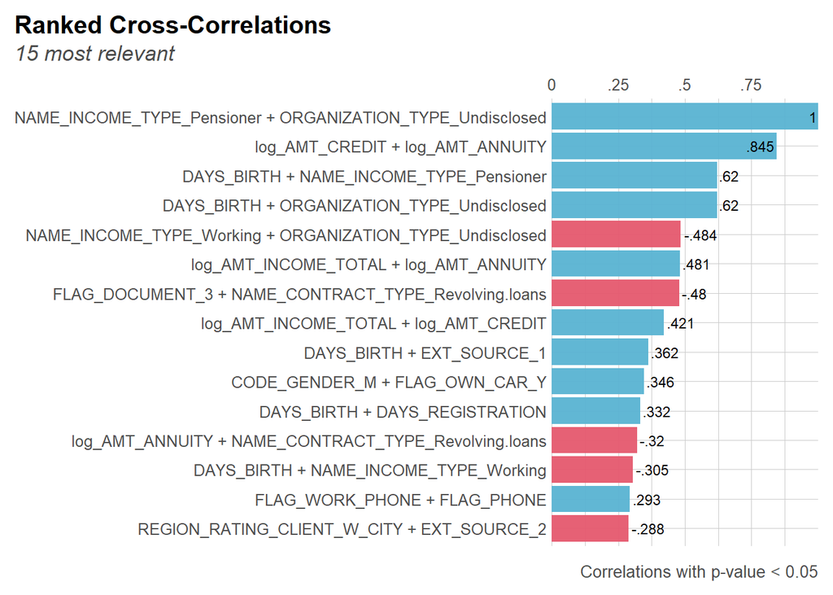

```r
#Remove highly correlated variables to reduce multicollinearity
 clean_train <- clean_train %>%
   select(
          -log_AMT_ANNUITY,
          -ORGANIZATION_TYPE
          )

 #Display top 15 correlated variables with p value greater than 0.05
 corr_cross(clean_train,
            max_pvalue = 0.05,
            top = 15
            )
```

```
## Returning only the top 15. You may override with the 'top' argument
```

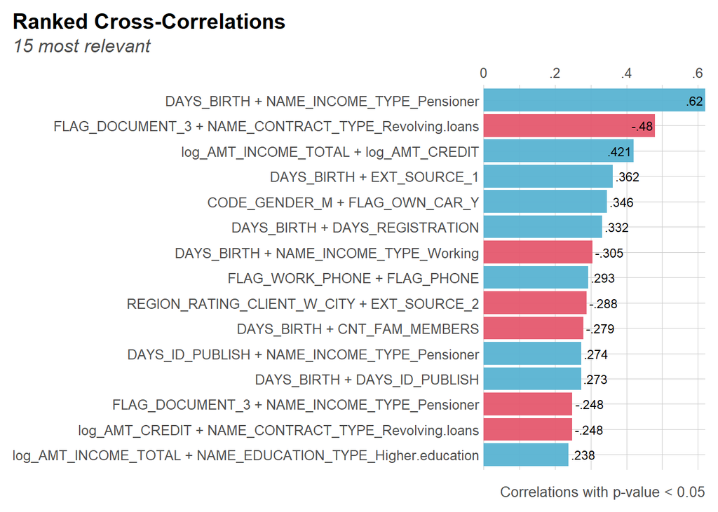

```r
#Check VIF
vif(glm(TARGET ~ ., data = clean_train, family = "binomial"))
```

```
##                                 GVIF Df GVIF^(1/(2*Df))
## NAME_CONTRACT_TYPE          1.415165  1        1.189607
## CODE_GENDER                 1.260257  1        1.122612
## FLAG_OWN_CAR                1.182404  1        1.087384
## FLAG_OWN_REALTY             1.048526  1        1.023975
## NAME_INCOME_TYPE            2.049084  7        1.052578
## NAME_EDUCATION_TYPE         1.137982  4        1.016288
## DAYS_BIRTH                  2.224120  1        1.491348
## DAYS_EMPLOYED               1.148038  1        1.071466
## DAYS_REGISTRATION           1.134491  1        1.065125
## DAYS_ID_PUBLISH             1.134806  1        1.065273
## FLAG_WORK_PHONE             1.209588  1        1.099813
## FLAG_PHONE                  1.131963  1        1.063938
## FLAG_EMAIL                  1.023053  1        1.011461
## CNT_FAM_MEMBERS             1.111931  1        1.054481
## REGION_RATING_CLIENT_W_CITY 1.129860  1        1.062949
## LIVE_REGION_NOT_WORK_REGION 1.044997  1        1.022251
## REG_CITY_NOT_LIVE_CITY      1.056274  1        1.027752
## EXT_SOURCE_1                1.264454  1        1.124480
## EXT_SOURCE_2                1.114819  1        1.055850
## EXT_SOURCE_3                1.052125  1        1.025731
## FLAG_DOCUMENT_3             1.455657  1        1.206506
## log_AMT_INCOME_TOTAL        1.475439  1        1.214676
## log_AMT_CREDIT              1.319862  1        1.148853
```

```r
#Show summary, comment out for brevity
#summary(clean_train)
```

Correlation between predictors examined, anything over 70% removed to reduce multicollinearity. VIF was checked to ensure no multicollinearity remained. Although many variables were already removed during EDA as they appeared to overlap.

```r
#write clean_train to csv
write.csv(clean_train, "clean_train.csv", row.names = FALSE)
```

```r
#load data
clean_train <- read_csv('clean_train.csv') %>%
  mutate_if(is.character, as.factor)

#set TARGET Variable as Factor with No and Yes for Levels (caret errors otherwise)
clean_train$TARGET <- factor(clean_train$TARGET,
                             levels = c(0, 1), labels = c('No', 'Yes'))
```

Load packages and the preprocessed data.

## Modeling Process

```r
#Validate Distribution of Target Variable
prop.table(table(clean_train$TARGET))
```

```
##
##         No        Yes
## 0.91927013 0.08072987
```

```r
#time
tic()

#Logistic Model
logicModel <- glm(TARGET ~ ., data = clean_train, family = binomial(link = 'logit'))

#time
toc()

#Summary of Model
# summary(logicModel)
```

Based on distribution of TARGET variable only 8.07% of customers defaulted on their loans. This is an unbalanced dataset, and we will need to address this in our modeling. The base logistic model with all variables from preprocessing ran in 7.5 seconds. AIC of base is 154960.

```r
#Variable Importance
varImp(logicModel, scale = TRUE)
```

```
##                                                      Overall
## NAME_CONTRACT_TYPERevolving loans                 8.78420020
## CODE_GENDERM                                     23.56500891
## FLAG_OWN_CARY                                    17.14491872
## FLAG_OWN_REALTYY                                  5.51651650
## NAME_INCOME_TYPECommercial associate              0.12419922
## NAME_INCOME_TYPEMaternity leave                   0.17172098
## NAME_INCOME_TYPEPensioner                         0.12055603
## NAME_INCOME_TYPEState servant                     0.12124446
## NAME_INCOME_TYPEStudent                           0.02231658
## NAME_INCOME_TYPEUnemployed                        0.15868905
## NAME_INCOME_TYPEWorking                           0.12583986
## NAME_EDUCATION_TYPEHigher education               2.14945052
## NAME_EDUCATION_TYPEIncomplete higher              2.37109971
## NAME_EDUCATION_TYPELower secondary                3.06478047
## NAME_EDUCATION_TYPESecondary / secondary special  2.81736444
## DAYS_BIRTH                                        1.32753812
## DAYS_EMPLOYED                                    19.37979875
## DAYS_REGISTRATION                                 4.49690301
## DAYS_ID_PUBLISH                                   9.60630114
## FLAG_WORK_PHONE                                   6.36150190
## FLAG_PHONE                                        6.56335505
## FLAG_EMAIL                                        2.49734309
## CNT_FAM_MEMBERS                                   1.39179444
## REGION_RATING_CLIENT_W_CITY                       9.87958999
## LIVE_REGION_NOT_WORK_REGION                       1.96100899
## REG_CITY_NOT_LIVE_CITY                            7.25934301
## EXT_SOURCE_1                                     22.20977034
## EXT_SOURCE_2                                     61.81587993
## EXT_SOURCE_3                                     69.95858724
## FLAG_DOCUMENT_3                                   8.76573595
## log_AMT_INCOME_TOTAL                              3.64975863
## log_AMT_CREDIT                                    8.82072719
```

```r
#Select Important variables over ~8% importance
varImp8 <- varImp(logicModel, scale = TRUE) %>%
  as.data.frame() %>%
  rownames_to_column() %>%
  filter(Overall > 8)

#Display Important Variables
varImp8
```

```
##                              rowname   Overall
## 1  NAME_CONTRACT_TYPERevolving loans  8.784200
## 2                       CODE_GENDERM 23.565009
## 3                      FLAG_OWN_CARY 17.144919
## 4                      DAYS_EMPLOYED 19.379799
## 5                    DAYS_ID_PUBLISH  9.606301
## 6        REGION_RATING_CLIENT_W_CITY  9.879590
## 7                       EXT_SOURCE_1 22.209770
## 8                       EXT_SOURCE_2 61.815880
## 9                       EXT_SOURCE_3 69.958587
## 10                   FLAG_DOCUMENT_3  8.765736
## 11                    log_AMT_CREDIT  8.820727
```

Predictor selection for the logistic was accomplished using varImp() to determine the most important variables in the logistic model. Variables with an importance of greater than 8% were selected for further analysis. After initial preprocessing of data this identified the following predictors: NAME_CONTRACT_TYPE, CODE_GENDER, FLAG_OWN_CAR+DAYS_EMPLOYED, DAYS_ID_PUBLISH, REGION_RATING_CLIENT_W_CITY, EXT_SOURCE_1, EXT_SOURCE_, EXT_SOURCE_3 , FLAG_DOCUMENT_3, and log_AMT_CREDIT.

```r
#set train control for downsampled data
traincntrlDown <- trainControl(method = 'repeatedcv',
                             number = 5,
                             repeats = 2,
                             classProbs = TRUE,
                             sampling = "down",
                             summaryFunction = twoClassSummary)

#set train control for upsampled data
traincntrlUp <- trainControl(method = 'repeatedcv',
                             number = 5,
                             repeats = 2,
                             classProbs = TRUE,
                             sampling = "up",
                             summaryFunction = twoClassSummary)
```

Set train control for downsampled and upsampled data using repeatee cross validation with 5 folds and 2 repeats. Class probabilities are set to true. Downsampling and upsampling are used to test addressing the unbalanced dataset.

```r
#Split train and test 70/30
set.seed(123)

#Create index for 70/30 split
inTrain <- createDataPartition(clean_train$TARGET, p = 0.7, list = FALSE)

#Create train and test datasets
appTrain <- clean_train[inTrain, ]
appTest <- clean_train[-inTrain, ]

#Check distribution of target variable in train and test
prop.table(table(appTrain$TARGET))
```

```
##
##         No        Yes
## 0.91926822 0.08073178
```

```r
prop.table(table(appTest$TARGET))
```

```
##
##         No        Yes
## 0.91927459 0.08072541
```

Split data into 70% train and 30% test sets. The target variable is still unbalanced in the train and test sets at 8.07%.

```r
#time
tic()

#Create logistic model with only important variables
logitModel <- glm(TARGET ~ NAME_CONTRACT_TYPE+CODE_GENDER+
                    FLAG_OWN_CAR+DAYS_EMPLOYED+
                    DAYS_ID_PUBLISH+REGION_RATING_CLIENT_W_CITY+
                    EXT_SOURCE_1+EXT_SOURCE_2+
                    EXT_SOURCE_3+FLAG_DOCUMENT_3+
                    log_AMT_CREDIT, data = clean_train,
                  family = binomial(link = 'logit'))

#time
toc()


#time
tic()

logitModelDown <- train(TARGET ~ NAME_CONTRACT_TYPE+CODE_GENDER+
                    FLAG_OWN_CAR+DAYS_EMPLOYED+
                    DAYS_ID_PUBLISH+REGION_RATING_CLIENT_W_CITY+
                    EXT_SOURCE_1+EXT_SOURCE_2+
                    EXT_SOURCE_3+FLAG_DOCUMENT_3+
                    log_AMT_CREDIT, data = clean_train,
                    method = "glm",
                    trControl = traincntrlDown)

#time
toc()

#time
tic()

logitModelUp <- train(TARGET ~ NAME_CONTRACT_TYPE+CODE_GENDER+
                    FLAG_OWN_CAR+DAYS_EMPLOYED+
                    DAYS_ID_PUBLISH+REGION_RATING_CLIENT_W_CITY+
                    EXT_SOURCE_1+EXT_SOURCE_2+
                    EXT_SOURCE_3+FLAG_DOCUMENT_3+
                    log_AMT_CREDIT, data = clean_train,
                    method = "glm",
                    trControl = traincntrlUp)
toc()

#Compare AIC of models
summary(logitModel)
```

```
##
## Call:
## glm(formula = TARGET ~ NAME_CONTRACT_TYPE + CODE_GENDER + FLAG_OWN_CAR +
##     DAYS_EMPLOYED + DAYS_ID_PUBLISH + REGION_RATING_CLIENT_W_CITY +
##     EXT_SOURCE_1 + EXT_SOURCE_2 + EXT_SOURCE_3 + FLAG_DOCUMENT_3 +
##     log_AMT_CREDIT, family = binomial(link = "logit"), data = clean_train)
##
## Coefficients:
##                                     Estimate Std. Error z value Pr(>|z|)
## (Intercept)                       -5.485e-01  1.424e-01  -3.851 0.000118 ***
## NAME_CONTRACT_TYPERevolving loans -2.388e-01  3.161e-02  -7.555 4.18e-14 ***
## CODE_GENDERM                       4.068e-01  1.506e-02  27.014  < 2e-16 ***
## FLAG_OWN_CARY                     -2.917e-01  1.580e-02 -18.462  < 2e-16 ***
## DAYS_EMPLOYED                     -8.035e-05  4.054e-06 -19.820  < 2e-16 ***
## DAYS_ID_PUBLISH                   -5.872e-05  4.604e-06 -12.752  < 2e-16 ***
## REGION_RATING_CLIENT_W_CITY        1.730e-01  1.413e-02  12.246  < 2e-16 ***
## EXT_SOURCE_1                      -1.324e+00  4.947e-02 -26.757  < 2e-16 ***
## EXT_SOURCE_2                      -2.240e+00  3.429e-02 -65.333  < 2e-16 ***
## EXT_SOURCE_3                      -2.634e+00  3.735e-02 -70.519  < 2e-16 ***
## FLAG_DOCUMENT_3                    2.672e-01  1.854e-02  14.410  < 2e-16 ***
## log_AMT_CREDIT                     6.082e-02  1.038e-02   5.860 4.62e-09 ***
## ---
## Signif. codes:  0 '***' 0.001 '**' 0.01 '*' 0.05 '.' 0.1 ' ' 1
##
## (Dispersion parameter for binomial family taken to be 1)
##
##     Null deviance: 172541  on 307506  degrees of freedom
## Residual deviance: 155955  on 307495  degrees of freedom
## AIC: 155979
##
## Number of Fisher Scoring iterations: 6
```

```r
summary(logitModelDown)
```

```
##
## Call:
## NULL
##
## Coefficients:
##                                       Estimate Std. Error z value Pr(>|z|)
## (Intercept)                          2.330e+00  2.095e-01  11.121  < 2e-16 ***
## `NAME_CONTRACT_TYPERevolving loans` -2.477e-01  4.279e-02  -5.788 7.13e-09 ***
## CODE_GENDERM                         4.035e-01  2.182e-02  18.491  < 2e-16 ***
## FLAG_OWN_CARY                       -3.080e-01  2.244e-02 -13.723  < 2e-16 ***
## DAYS_EMPLOYED                       -7.660e-05  5.261e-06 -14.559  < 2e-16 ***
## DAYS_ID_PUBLISH                     -6.975e-05  6.543e-06 -10.661  < 2e-16 ***
## REGION_RATING_CLIENT_W_CITY          1.792e-01  2.044e-02   8.763  < 2e-16 ***
## EXT_SOURCE_1                        -1.585e+00  7.479e-02 -21.193  < 2e-16 ***
## EXT_SOURCE_2                        -2.230e+00  5.132e-02 -43.464  < 2e-16 ***
## EXT_SOURCE_3                        -2.719e+00  5.556e-02 -48.940  < 2e-16 ***
## FLAG_DOCUMENT_3                      2.355e-01  2.570e-02   9.163  < 2e-16 ***
## log_AMT_CREDIT                       4.225e-02  1.523e-02   2.774  0.00554 **
## ---
## Signif. codes:  0 '***' 0.001 '**' 0.01 '*' 0.05 '.' 0.1 ' ' 1
##
## (Dispersion parameter for binomial family taken to be 1)
##
##     Null deviance: 68830  on 49649  degrees of freedom
## Residual deviance: 60211  on 49638  degrees of freedom
## AIC: 60235
##
## Number of Fisher Scoring iterations: 4
```

```r
summary(logitModelUp)
```

```
##
## Call:
## NULL
##
## Coefficients:
##                                       Estimate Std. Error z value Pr(>|z|)
## (Intercept)                          1.919e+00  6.202e-02   30.94   <2e-16 ***
## `NAME_CONTRACT_TYPERevolving loans` -2.318e-01  1.260e-02  -18.40   <2e-16 ***
## CODE_GENDERM                         4.248e-01  6.490e-03   65.44   <2e-16 ***
## FLAG_OWN_CARY                       -3.071e-01  6.666e-03  -46.08   <2e-16 ***
## DAYS_EMPLOYED                       -7.931e-05  1.559e-06  -50.85   <2e-16 ***
## DAYS_ID_PUBLISH                     -6.186e-05  1.941e-06  -31.87   <2e-16 ***
## REGION_RATING_CLIENT_W_CITY          1.796e-01  6.084e-03   29.52   <2e-16 ***
## EXT_SOURCE_1                        -1.552e+00  2.210e-02  -70.23   <2e-16 ***
## EXT_SOURCE_2                        -2.277e+00  1.525e-02 -149.36   <2e-16 ***
## EXT_SOURCE_3                        -2.674e+00  1.646e-02 -162.43   <2e-16 ***
## FLAG_DOCUMENT_3                      2.539e-01  7.616e-03   33.34   <2e-16 ***
## log_AMT_CREDIT                       6.931e-02  4.504e-03   15.39   <2e-16 ***
## ---
## Signif. codes:  0 '***' 0.001 '**' 0.01 '*' 0.05 '.' 0.1 ' ' 1
##
## (Dispersion parameter for binomial family taken to be 1)
##
##     Null deviance: 783761  on 565363  degrees of freedom
## Residual deviance: 685555  on 565352  degrees of freedom
## AIC: 685579
##
## Number of Fisher Scoring iterations: 4
```

```r
#Balanced data set with both over and under sampling
data.balanced.ou <- ovun.sample(TARGET~., data=appTrain,
                                N=nrow(appTrain), p=0.5,
                                seed=1, method="both")$data

#Check distribution of target variable in balanced data
table(data.balanced.ou$TARGET)
```

```
##
##     No    Yes
## 107498 107758
```

```r
#Balanced data set with over-sampling
data.balanced.over <- ovun.sample(TARGET~., data=appTrain,
                                  p=0.5, seed=1,
                                  method="over")$data

#Check distribution of target variable in oversampled
table(data.balanced.over$TARGET)
```

```
##
##     No    Yes
## 197878 198122
```

```r
#Balanced data set with under-sampling
data.balanced.under <- ovun.sample(TARGET~., data=appTrain,
                                   p=0.5, seed=1,
                                   method="under")$data

#Check distribution of target variable in undersampled data
table(data.balanced.under$TARGET)
```

```
##
##    No   Yes
## 17314 17378
```

```r
#time
tic()

#Logistic Model with balanced data
logicModelou<- glm(TARGET ~ NAME_CONTRACT_TYPE+CODE_GENDER+
                    FLAG_OWN_CAR+DAYS_EMPLOYED+
                    DAYS_ID_PUBLISH+REGION_RATING_CLIENT_W_CITY+
                    EXT_SOURCE_1+EXT_SOURCE_2+
                    EXT_SOURCE_3+FLAG_DOCUMENT_3+
                    log_AMT_CREDIT, data = data.balanced.ou,
                  family = binomial(link = 'logit'))

#time
toc()

#Distribution of target variable in balanced data
table(data.balanced.ou$TARGET)
```

```
##
##     No    Yes
## 107498 107758
```

```r
#Summary of Logistic Model over/under
summary(logicModelou)
```

```
##
## Call:
## glm(formula = TARGET ~ NAME_CONTRACT_TYPE + CODE_GENDER + FLAG_OWN_CAR +
##     DAYS_EMPLOYED + DAYS_ID_PUBLISH + REGION_RATING_CLIENT_W_CITY +
##     EXT_SOURCE_1 + EXT_SOURCE_2 + EXT_SOURCE_3 + FLAG_DOCUMENT_3 +
##     log_AMT_CREDIT, family = binomial(link = "logit"), data = data.balanced.ou)
##
## Coefficients:
##                                     Estimate Std. Error  z value Pr(>|z|)
## (Intercept)                        1.980e+00  1.003e-01   19.737   <2e-16 ***
## NAME_CONTRACT_TYPERevolving loans -2.142e-01  2.043e-02  -10.483   <2e-16 ***
## CODE_GENDERM                       4.467e-01  1.054e-02   42.379   <2e-16 ***
## FLAG_OWN_CARY                     -3.077e-01  1.081e-02  -28.455   <2e-16 ***
## DAYS_EMPLOYED                     -7.319e-05  2.517e-06  -29.074   <2e-16 ***
## DAYS_ID_PUBLISH                   -6.921e-05  3.140e-06  -22.040   <2e-16 ***
## REGION_RATING_CLIENT_W_CITY        1.900e-01  9.905e-03   19.186   <2e-16 ***
## EXT_SOURCE_1                      -1.552e+00  3.575e-02  -43.404   <2e-16 ***
## EXT_SOURCE_2                      -2.230e+00  2.470e-02  -90.266   <2e-16 ***
## EXT_SOURCE_3                      -2.717e+00  2.664e-02 -101.982   <2e-16 ***
## FLAG_DOCUMENT_3                    2.521e-01  1.238e-02   20.358   <2e-16 ***
## log_AMT_CREDIT                     6.294e-02  7.291e-03    8.633   <2e-16 ***
## ---
## Signif. codes:  0 '***' 0.001 '**' 0.01 '*' 0.05 '.' 0.1 ' ' 1
##
## (Dispersion parameter for binomial family taken to be 1)
##
##     Null deviance: 298408  on 215255  degrees of freedom
## Residual deviance: 260959  on 215244  degrees of freedom
## AIC: 260983
##
## Number of Fisher Scoring iterations: 4
```

```r
#time
tic()

#Logistic Model with balanced data using upsampled data
logicModelover <- glm(TARGET ~ NAME_CONTRACT_TYPE+CODE_GENDER+
                    FLAG_OWN_CAR+DAYS_EMPLOYED+
                    DAYS_ID_PUBLISH+REGION_RATING_CLIENT_W_CITY+
                    EXT_SOURCE_1+EXT_SOURCE_2+
                    EXT_SOURCE_3+FLAG_DOCUMENT_3+
                    log_AMT_CREDIT, data = data.balanced.over,
                  family = binomial(link = 'logit'))

#time
toc()

#Distribution of target variable in balanced data
table(data.balanced.over$TARGET)
```

```
##
##     No    Yes
## 197878 198122
```

```r
#Summary of Logistic Model over
summary(logicModelover)
```

```
##
## Call:
## glm(formula = TARGET ~ NAME_CONTRACT_TYPE + CODE_GENDER + FLAG_OWN_CAR +
##     DAYS_EMPLOYED + DAYS_ID_PUBLISH + REGION_RATING_CLIENT_W_CITY +
##     EXT_SOURCE_1 + EXT_SOURCE_2 + EXT_SOURCE_3 + FLAG_DOCUMENT_3 +
##     log_AMT_CREDIT, family = binomial(link = "logit"), data = data.balanced.over)
##
## Coefficients:
##                                     Estimate Std. Error z value Pr(>|z|)
## (Intercept)                        1.966e+00  7.401e-02   26.57   <2e-16 ***
## NAME_CONTRACT_TYPERevolving loans -2.142e-01  1.504e-02  -14.24   <2e-16 ***
## CODE_GENDERM                       4.403e-01  7.757e-03   56.76   <2e-16 ***
## FLAG_OWN_CARY                     -2.944e-01  7.965e-03  -36.96   <2e-16 ***
## DAYS_EMPLOYED                     -7.517e-05  1.853e-06  -40.57   <2e-16 ***
## DAYS_ID_PUBLISH                   -6.926e-05  2.313e-06  -29.94   <2e-16 ***
## REGION_RATING_CLIENT_W_CITY        1.813e-01  7.282e-03   24.89   <2e-16 ***
## EXT_SOURCE_1                      -1.542e+00  2.639e-02  -58.42   <2e-16 ***
## EXT_SOURCE_2                      -2.271e+00  1.827e-02 -124.27   <2e-16 ***
## EXT_SOURCE_3                      -2.667e+00  1.963e-02 -135.88   <2e-16 ***
## FLAG_DOCUMENT_3                    2.580e-01  9.127e-03   28.26   <2e-16 ***
## log_AMT_CREDIT                     6.464e-02  5.378e-03   12.02   <2e-16 ***
## ---
## Signif. codes:  0 '***' 0.001 '**' 0.01 '*' 0.05 '.' 0.1 ' ' 1
##
## (Dispersion parameter for binomial family taken to be 1)
##
##     Null deviance: 548972  on 395999  degrees of freedom
## Residual deviance: 480214  on 395988  degrees of freedom
## AIC: 480238
##
## Number of Fisher Scoring iterations: 4
```

```r
#time
tic()

#Logistic Model with balanced data using downsampled data
logicModelunder <- glm(TARGET ~ NAME_CONTRACT_TYPE+CODE_GENDER+
                    FLAG_OWN_CAR+DAYS_EMPLOYED+
                    DAYS_ID_PUBLISH+REGION_RATING_CLIENT_W_CITY+
                    EXT_SOURCE_1+EXT_SOURCE_2+
                    EXT_SOURCE_3+FLAG_DOCUMENT_3+
                    log_AMT_CREDIT, data = data.balanced.under,
                  family = binomial(link = 'logit'))
#time
toc()

#Distribution of target variable in balanced data
table(data.balanced.under$TARGET)
```

```
##
##    No   Yes
## 17314 17378
```

```r
#Summary of Logistic Model under
summary(logicModelunder)
```

```
##
## Call:
## glm(formula = TARGET ~ NAME_CONTRACT_TYPE + CODE_GENDER + FLAG_OWN_CAR +
##     DAYS_EMPLOYED + DAYS_ID_PUBLISH + REGION_RATING_CLIENT_W_CITY +
##     EXT_SOURCE_1 + EXT_SOURCE_2 + EXT_SOURCE_3 + FLAG_DOCUMENT_3 +
##     log_AMT_CREDIT, family = binomial(link = "logit"), data = data.balanced.under)
##
## Coefficients:
##                                     Estimate Std. Error z value Pr(>|z|)
## (Intercept)                        2.010e+00  2.513e-01   7.998 1.26e-15 ***
## NAME_CONTRACT_TYPERevolving loans -2.249e-01  5.072e-02  -4.435 9.22e-06 ***
## CODE_GENDERM                       4.484e-01  2.619e-02  17.123  < 2e-16 ***
## FLAG_OWN_CARY                     -2.692e-01  2.690e-02 -10.008  < 2e-16 ***
## DAYS_EMPLOYED                     -7.627e-05  6.237e-06 -12.229  < 2e-16 ***
## DAYS_ID_PUBLISH                   -5.617e-05  7.813e-06  -7.189 6.52e-13 ***
## REGION_RATING_CLIENT_W_CITY        1.546e-01  2.455e-02   6.298 3.02e-10 ***
## EXT_SOURCE_1                      -1.458e+00  8.908e-02 -16.369  < 2e-16 ***
## EXT_SOURCE_2                      -2.253e+00  6.147e-02 -36.642  < 2e-16 ***
## EXT_SOURCE_3                      -2.704e+00  6.633e-02 -40.758  < 2e-16 ***
## FLAG_DOCUMENT_3                    2.902e-01  3.081e-02   9.418  < 2e-16 ***
## log_AMT_CREDIT                     5.766e-02  1.826e-02   3.157  0.00159 **
## ---
## Signif. codes:  0 '***' 0.001 '**' 0.01 '*' 0.05 '.' 0.1 ' ' 1
##
## (Dispersion parameter for binomial family taken to be 1)
##
##     Null deviance: 48093  on 34691  degrees of freedom
## Residual deviance: 42138  on 34680  degrees of freedom
## AIC: 42162
##
## Number of Fisher Scoring iterations: 4
```

```r
#time
tic()

#Downsampled model with interactions
logicModelunderInt <- glm(formula = TARGET ~ NAME_CONTRACT_TYPE + CODE_GENDER + FLAG_OWN_CAR +
    DAYS_EMPLOYED + DAYS_ID_PUBLISH + REGION_RATING_CLIENT_W_CITY +
    EXT_SOURCE_1 + EXT_SOURCE_2 + EXT_SOURCE_3 + FLAG_DOCUMENT_3 +
    log_AMT_CREDIT + FLAG_OWN_CAR:EXT_SOURCE_1 + DAYS_ID_PUBLISH:FLAG_DOCUMENT_3 +
    NAME_CONTRACT_TYPE:CODE_GENDER + NAME_CONTRACT_TYPE:FLAG_OWN_CAR +
    DAYS_EMPLOYED:FLAG_DOCUMENT_3 + DAYS_ID_PUBLISH:EXT_SOURCE_1 +
    CODE_GENDER:EXT_SOURCE_1 + EXT_SOURCE_1:FLAG_DOCUMENT_3 +
    NAME_CONTRACT_TYPE:DAYS_EMPLOYED + CODE_GENDER:EXT_SOURCE_3 +
    FLAG_OWN_CAR:EXT_SOURCE_3 + REGION_RATING_CLIENT_W_CITY:EXT_SOURCE_1 +
    CODE_GENDER:REGION_RATING_CLIENT_W_CITY, family = binomial(link = "logit"),
    data = data.balanced.under)
#time
toc()

#Summary of model
summary(logicModelunderInt)
```

```
##
## Call:
## glm(formula = TARGET ~ NAME_CONTRACT_TYPE + CODE_GENDER + FLAG_OWN_CAR +
##     DAYS_EMPLOYED + DAYS_ID_PUBLISH + REGION_RATING_CLIENT_W_CITY +
##     EXT_SOURCE_1 + EXT_SOURCE_2 + EXT_SOURCE_3 + FLAG_DOCUMENT_3 +
##     log_AMT_CREDIT + FLAG_OWN_CAR:EXT_SOURCE_1 + DAYS_ID_PUBLISH:FLAG_DOCUMENT_3 +
##     NAME_CONTRACT_TYPE:CODE_GENDER + NAME_CONTRACT_TYPE:FLAG_OWN_CAR +
##     DAYS_EMPLOYED:FLAG_DOCUMENT_3 + DAYS_ID_PUBLISH:EXT_SOURCE_1 +
##     CODE_GENDER:EXT_SOURCE_1 + EXT_SOURCE_1:FLAG_DOCUMENT_3 +
##     NAME_CONTRACT_TYPE:DAYS_EMPLOYED + CODE_GENDER:EXT_SOURCE_3 +
##     FLAG_OWN_CAR:EXT_SOURCE_3 + REGION_RATING_CLIENT_W_CITY:EXT_SOURCE_1 +
##     CODE_GENDER:REGION_RATING_CLIENT_W_CITY, family = binomial(link = "logit"),
##     data = data.balanced.under)
##
## Coefficients:
##                                                   Estimate Std. Error z value
## (Intercept)                                      2.589e+00  3.314e-01   7.813
## NAME_CONTRACT_TYPERevolving loans               -9.005e-03  8.368e-02  -0.108
## CODE_GENDERM                                    -7.650e-01  1.548e-01  -4.943
## FLAG_OWN_CARY                                    1.217e-01  1.167e-01   1.043
## DAYS_EMPLOYED                                   -6.286e-05  1.797e-05  -3.497
## DAYS_ID_PUBLISH                                  2.755e-05  3.263e-05   0.844
## REGION_RATING_CLIENT_W_CITY                     -2.209e-01  9.089e-02  -2.431
## EXT_SOURCE_1                                    -2.323e+00  4.341e-01  -5.351
## EXT_SOURCE_2                                    -2.245e+00  6.161e-02 -36.433
## EXT_SOURCE_3                                    -2.794e+00  8.978e-02 -31.118
## FLAG_DOCUMENT_3                                  4.326e-01  1.141e-01   3.793
## log_AMT_CREDIT                                   6.091e-02  1.832e-02   3.326
## FLAG_OWN_CARY:EXT_SOURCE_1                      -3.936e-01  1.933e-01  -2.036
## DAYS_ID_PUBLISH:FLAG_DOCUMENT_3                  2.046e-05  1.801e-05   1.136
## NAME_CONTRACT_TYPERevolving loans:CODE_GENDERM  -2.543e-01  9.578e-02  -2.655
## NAME_CONTRACT_TYPERevolving loans:FLAG_OWN_CARY -1.551e-02  9.788e-02  -0.158
## DAYS_EMPLOYED:FLAG_DOCUMENT_3                   -1.185e-05  1.917e-05  -0.618
## DAYS_ID_PUBLISH:EXT_SOURCE_1                    -2.011e-04  5.872e-05  -3.425
## CODE_GENDERM:EXT_SOURCE_1                        1.236e+00  1.893e-01   6.530
## EXT_SOURCE_1:FLAG_DOCUMENT_3                    -3.933e-01  2.033e-01  -1.934
## NAME_CONTRACT_TYPERevolving loans:DAYS_EMPLOYED -7.516e-05  3.077e-05  -2.443
## CODE_GENDERM:EXT_SOURCE_3                        6.090e-01  1.452e-01   4.195
## FLAG_OWN_CARY:EXT_SOURCE_3                      -4.446e-01  1.494e-01  -2.976
## REGION_RATING_CLIENT_W_CITY:EXT_SOURCE_1         6.441e-01  1.711e-01   3.765
```

[output cut: 22 more lines]

```
## NAME_CONTRACT_TYPERevolving loans:DAYS_EMPLOYED 0.014574 *
## CODE_GENDERM:EXT_SOURCE_3                       2.73e-05 ***
## FLAG_OWN_CARY:EXT_SOURCE_3                      0.002923 **
## REGION_RATING_CLIENT_W_CITY:EXT_SOURCE_1        0.000166 ***
## CODE_GENDERM:REGION_RATING_CLIENT_W_CITY        0.000502 ***
## ---
## Signif. codes:  0 '***' 0.001 '**' 0.01 '*' 0.05 '.' 0.1 ' ' 1
##
## (Dispersion parameter for binomial family taken to be 1)
##
##     Null deviance: 48093  on 34691  degrees of freedom
## Residual deviance: 42018  on 34667  degrees of freedom
## AIC: 42068
##
## Number of Fisher Scoring iterations: 4
```

```r
#time
tic()

#Upsampled model with downsampled interacations
logicModelunderIntover <- glm(formula = TARGET ~ NAME_CONTRACT_TYPE + CODE_GENDER + FLAG_OWN_CAR +
    DAYS_EMPLOYED + DAYS_ID_PUBLISH + REGION_RATING_CLIENT_W_CITY +
    EXT_SOURCE_1 + EXT_SOURCE_2 + EXT_SOURCE_3 + FLAG_DOCUMENT_3 +
    log_AMT_CREDIT + FLAG_OWN_CAR:EXT_SOURCE_1 + DAYS_ID_PUBLISH:FLAG_DOCUMENT_3 +
    NAME_CONTRACT_TYPE:CODE_GENDER + NAME_CONTRACT_TYPE:FLAG_OWN_CAR +
    DAYS_EMPLOYED:FLAG_DOCUMENT_3 + DAYS_ID_PUBLISH:EXT_SOURCE_1 +
    CODE_GENDER:EXT_SOURCE_1 + EXT_SOURCE_1:FLAG_DOCUMENT_3 +
    NAME_CONTRACT_TYPE:DAYS_EMPLOYED + CODE_GENDER:EXT_SOURCE_3 +
    FLAG_OWN_CAR:EXT_SOURCE_3 + REGION_RATING_CLIENT_W_CITY:EXT_SOURCE_1 +
    CODE_GENDER:REGION_RATING_CLIENT_W_CITY, family = binomial(link = "logit"),
    data = data.balanced.over)
#time
toc()

#summary
summary(logicModelunderIntover)
```

```
##
## Call:
## glm(formula = TARGET ~ NAME_CONTRACT_TYPE + CODE_GENDER + FLAG_OWN_CAR +
##     DAYS_EMPLOYED + DAYS_ID_PUBLISH + REGION_RATING_CLIENT_W_CITY +
##     EXT_SOURCE_1 + EXT_SOURCE_2 + EXT_SOURCE_3 + FLAG_DOCUMENT_3 +
##     log_AMT_CREDIT + FLAG_OWN_CAR:EXT_SOURCE_1 + DAYS_ID_PUBLISH:FLAG_DOCUMENT_3 +
##     NAME_CONTRACT_TYPE:CODE_GENDER + NAME_CONTRACT_TYPE:FLAG_OWN_CAR +
##     DAYS_EMPLOYED:FLAG_DOCUMENT_3 + DAYS_ID_PUBLISH:EXT_SOURCE_1 +
##     CODE_GENDER:EXT_SOURCE_1 + EXT_SOURCE_1:FLAG_DOCUMENT_3 +
##     NAME_CONTRACT_TYPE:DAYS_EMPLOYED + CODE_GENDER:EXT_SOURCE_3 +
##     FLAG_OWN_CAR:EXT_SOURCE_3 + REGION_RATING_CLIENT_W_CITY:EXT_SOURCE_1 +
##     CODE_GENDER:REGION_RATING_CLIENT_W_CITY, family = binomial(link = "logit"),
##     data = data.balanced.over)
##
## Coefficients:
##                                                   Estimate Std. Error  z value
## (Intercept)                                      2.222e+00  9.815e-02   22.639
## NAME_CONTRACT_TYPERevolving loans               -3.421e-02  2.484e-02   -1.377
## CODE_GENDERM                                    -4.957e-01  4.571e-02  -10.844
## FLAG_OWN_CARY                                   -6.492e-02  3.445e-02   -1.885
## DAYS_EMPLOYED                                   -5.266e-05  5.391e-06   -9.767
## DAYS_ID_PUBLISH                                  1.266e-05  9.692e-06    1.306
## REGION_RATING_CLIENT_W_CITY                      8.505e-03  2.725e-02    0.312
## EXT_SOURCE_1                                    -2.009e+00  1.291e-01  -15.563
## EXT_SOURCE_2                                    -2.264e+00  1.830e-02 -123.702
## EXT_SOURCE_3                                    -2.753e+00  2.661e-02 -103.460
## FLAG_DOCUMENT_3                                  3.581e-01  3.411e-02   10.497
## log_AMT_CREDIT                                   6.732e-02  5.390e-03   12.491
## FLAG_OWN_CARY:EXT_SOURCE_1                      -2.280e-01  5.720e-02   -3.986
## DAYS_ID_PUBLISH:FLAG_DOCUMENT_3                  1.861e-06  5.342e-06    0.348
## NAME_CONTRACT_TYPERevolving loans:CODE_GENDERM  -2.515e-01  2.831e-02   -8.883
## NAME_CONTRACT_TYPERevolving loans:FLAG_OWN_CARY  6.621e-02  2.890e-02    2.291
## DAYS_EMPLOYED:FLAG_DOCUMENT_3                   -2.253e-05  5.738e-06   -3.926
## DAYS_ID_PUBLISH:EXT_SOURCE_1                    -1.671e-04  1.739e-05   -9.609
## CODE_GENDERM:EXT_SOURCE_1                        1.214e+00  5.624e-02   21.588
## EXT_SOURCE_1:FLAG_DOCUMENT_3                    -1.440e-01  6.048e-02   -2.381
## NAME_CONTRACT_TYPERevolving loans:DAYS_EMPLOYED -6.639e-05  8.986e-06   -7.389
## CODE_GENDERM:EXT_SOURCE_3                        4.624e-01  4.293e-02   10.773
## FLAG_OWN_CARY:EXT_SOURCE_3                      -2.792e-01  4.414e-02   -6.326
## REGION_RATING_CLIENT_W_CITY:EXT_SOURCE_1         2.976e-01  5.116e-02    5.816
```

[output cut: 22 more lines]

```
## NAME_CONTRACT_TYPERevolving loans:DAYS_EMPLOYED 1.48e-13 ***
## CODE_GENDERM:EXT_SOURCE_3                        < 2e-16 ***
## FLAG_OWN_CARY:EXT_SOURCE_3                      2.51e-10 ***
## REGION_RATING_CLIENT_W_CITY:EXT_SOURCE_1        6.02e-09 ***
## CODE_GENDERM:REGION_RATING_CLIENT_W_CITY        2.28e-07 ***
## ---
## Signif. codes:  0 '***' 0.001 '**' 0.01 '*' 0.05 '.' 0.1 ' ' 1
##
## (Dispersion parameter for binomial family taken to be 1)
##
##     Null deviance: 548972  on 395999  degrees of freedom
## Residual deviance: 479310  on 395975  degrees of freedom
## AIC: 479360
##
## Number of Fisher Scoring iterations: 4
```

```r
#Upsampled model with upsampled interactions

#time
tic()
logicModeloverInt <- glm(formula = TARGET ~ NAME_CONTRACT_TYPE + CODE_GENDER + FLAG_OWN_CAR +
DAYS_EMPLOYED + DAYS_ID_PUBLISH + REGION_RATING_CLIENT_W_CITY +
EXT_SOURCE_1 + EXT_SOURCE_2 + EXT_SOURCE_3 + FLAG_DOCUMENT_3 + log_AMT_CREDIT + CODE_GENDER:EXT_SOURCE_1 + NAME_CONTRACT_TYPE:log_AMT_CREDIT + EXT_SOURCE_1:EXT_SOURCE_2 +
CODE_GENDER:EXT_SOURCE_2 + CODE_GENDER:EXT_SOURCE_3 +
DAYS_ID_PUBLISH:log_AMT_CREDIT + DAYS_ID_PUBLISH: EXT_SOURCE_1 +
CODE_GENDER:log_AMT_CREDIT + NAME_CONTRACT_TYPE: CODE_GENDER +
EXT_SOURCE_1:log_AMT_CREDIT + FLAG_DOCUMENT_3:log_AMT_CREDIT +
DAYS_ID_PUBLISH:EXT_SOURCE_3 + REGION_RATING_CLIENT_W_CITY:log_AMT_CREDIT +
FLAG_OWN_CAR:EXT_SOURCE_3 + EXT_SOURCE_2:EXT_SOURCE_3 + DAYS_EMPLOYED:EXT_SOURCE_2 +
DAYS_EMPLOYED:EXT_SOURCE_3 + EXT_SOURCE_3:log_AMT_CREDIT +
EXT_SOURCE_2:log_AMT_CREDIT + DAYS_EMPLOYED:EXT_SOURCE_1 +
FLAG_OWN_CAR:DAYS_ID_PUBLISH + NAME_CONTRACT_TYPE :EXT_SOURCE_2 +
EXT_SOURCE_1:EXT_SOURCE_3 + DAYS_EMPLOYED:REGION_RATING_CLIENT_W_CITY +
CODE_GENDER:DAYS_EMPLOYED + FLAG_OWN_CAR:REGION_RATING_CLIENT_W_CITY +
EXT_SOURCE_2:FLAG_DOCUMENT_3 + REGION_RATING_CLIENT_W_CITY:EXT_SOURCE_2 +
NAME_CONTRACT_TYPE: FLAG_OWN_CAR + NAME_CONTRACT_TYPE:DAYS_EMPLOYED +
DAYS_EMPLOYED:FLAG_DOCUMENT_3 + CODE_GENDER:DAYS_ID_PUBLISH +
FLAG_OWN_CAR:EXT_SOURCE_1 + REGION_RATING_CLIENT_W_CITY:EXT_SOURCE_3 +
NAME_CONTRACT_TYPE: REGION_RATING_CLIENT_W_CITY + CODE_GENDER:FLAG_OWN_CAR +
EXT_SOURCE_1:FLAG_DOCUMENT_3 + NAME_CONTRACT_TYPE:EXT_SOURCE_3 +
REGION_RATING_CLIENT_W_CITY:FLAG_DOCUMENT_3 + DAYS_ID_PUBLISH:EXT_SOURCE_2 +
FLAG_OWN_CAR:DAYS_EMPLOYED + FLAG_OWN_CAR:EXT_SOURCE_2, family = binomial(link = "logit"),
data = data.balanced.over)

#time
toc()

#Summary of model
summary(logicModeloverInt)
```

```
##
## Call:
## glm(formula = TARGET ~ NAME_CONTRACT_TYPE + CODE_GENDER + FLAG_OWN_CAR +
##     DAYS_EMPLOYED + DAYS_ID_PUBLISH + REGION_RATING_CLIENT_W_CITY +
##     EXT_SOURCE_1 + EXT_SOURCE_2 + EXT_SOURCE_3 + FLAG_DOCUMENT_3 +
##     log_AMT_CREDIT + CODE_GENDER:EXT_SOURCE_1 + NAME_CONTRACT_TYPE:log_AMT_CREDIT +
##     EXT_SOURCE_1:EXT_SOURCE_2 + CODE_GENDER:EXT_SOURCE_2 + CODE_GENDER:EXT_SOURCE_3 +
##     DAYS_ID_PUBLISH:log_AMT_CREDIT + DAYS_ID_PUBLISH:EXT_SOURCE_1 +
##     CODE_GENDER:log_AMT_CREDIT + NAME_CONTRACT_TYPE:CODE_GENDER +
##     EXT_SOURCE_1:log_AMT_CREDIT + FLAG_DOCUMENT_3:log_AMT_CREDIT +
##     DAYS_ID_PUBLISH:EXT_SOURCE_3 + REGION_RATING_CLIENT_W_CITY:log_AMT_CREDIT +
##     FLAG_OWN_CAR:EXT_SOURCE_3 + EXT_SOURCE_2:EXT_SOURCE_3 + DAYS_EMPLOYED:EXT_SOURCE_2 +
##     DAYS_EMPLOYED:EXT_SOURCE_3 + EXT_SOURCE_3:log_AMT_CREDIT +
##     EXT_SOURCE_2:log_AMT_CREDIT + DAYS_EMPLOYED:EXT_SOURCE_1 +
##     FLAG_OWN_CAR:DAYS_ID_PUBLISH + NAME_CONTRACT_TYPE:EXT_SOURCE_2 +
##     EXT_SOURCE_1:EXT_SOURCE_3 + DAYS_EMPLOYED:REGION_RATING_CLIENT_W_CITY +
##     CODE_GENDER:DAYS_EMPLOYED + FLAG_OWN_CAR:REGION_RATING_CLIENT_W_CITY +
##     EXT_SOURCE_2:FLAG_DOCUMENT_3 + REGION_RATING_CLIENT_W_CITY:EXT_SOURCE_2 +
##     NAME_CONTRACT_TYPE:FLAG_OWN_CAR + NAME_CONTRACT_TYPE:DAYS_EMPLOYED +
##     DAYS_EMPLOYED:FLAG_DOCUMENT_3 + CODE_GENDER:DAYS_ID_PUBLISH +
##     FLAG_OWN_CAR:EXT_SOURCE_1 + REGION_RATING_CLIENT_W_CITY:EXT_SOURCE_3 +
##     NAME_CONTRACT_TYPE:REGION_RATING_CLIENT_W_CITY + CODE_GENDER:FLAG_OWN_CAR +
##     EXT_SOURCE_1:FLAG_DOCUMENT_3 + NAME_CONTRACT_TYPE:EXT_SOURCE_3 +
##     REGION_RATING_CLIENT_W_CITY:FLAG_DOCUMENT_3 + DAYS_ID_PUBLISH:EXT_SOURCE_2 +
##     FLAG_OWN_CAR:DAYS_EMPLOYED + FLAG_OWN_CAR:EXT_SOURCE_2, family = binomial(link = "logit"),
##     data = data.balanced.over)
##
## Coefficients:
##                                                                 Estimate
## (Intercept)                                                    7.696e-01
## NAME_CONTRACT_TYPERevolving loans                              5.380e+00
## CODE_GENDERM                                                   1.558e+00
## FLAG_OWN_CARY                                                 -2.746e-01
## DAYS_EMPLOYED                                                  3.489e-05
## DAYS_ID_PUBLISH                                               -3.838e-04
## REGION_RATING_CLIENT_W_CITY                                   -7.532e-01
## EXT_SOURCE_1                                                   3.258e+00
## EXT_SOURCE_2                                                   7.771e-01
## EXT_SOURCE_3                                                  -4.542e+00
## FLAG_DOCUMENT_3                                                1.545e+00
```

[output cut: 203 more lines]

```
## NAME_CONTRACT_TYPERevolving loans:EXT_SOURCE_3                *
## REGION_RATING_CLIENT_W_CITY:FLAG_DOCUMENT_3                   .
## DAYS_ID_PUBLISH:EXT_SOURCE_2
## FLAG_OWN_CARY:DAYS_EMPLOYED
## FLAG_OWN_CARY:EXT_SOURCE_2
## ---
## Signif. codes:  0 '***' 0.001 '**' 0.01 '*' 0.05 '.' 0.1 ' ' 1
##
## (Dispersion parameter for binomial family taken to be 1)
##
##     Null deviance: 548972  on 395999  degrees of freedom
## Residual deviance: 478077  on 395946  degrees of freedom
## AIC: 478185
##
## Number of Fisher Scoring iterations: 4
```

## Model Performance

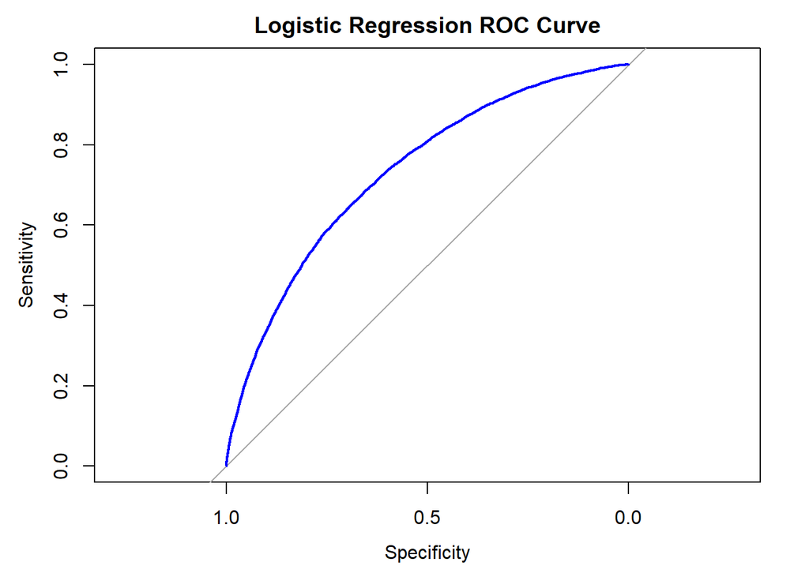

```r
#Predict downsampled with interactions on Test Data
logicPredunderInt <- predict(logicModelunderInt, appTest, type = 'response')

#Create ROC Curve
logicROCunderInt <- roc(appTest$TARGET, logicPredunderInt)
#Plot ROC Curve
plot(logicROCunderInt, col = 'blue', main = 'Logistic Regression ROC Curve')
```

```r
#Calculate AUC
auc(logicROCunderInt)
```

```
## Area under the curve: 0.7326
```

```r
#Threshold to predict
logicPredunderInt$predictor <- ifelse(logicPredunderInt > 0.5, "Yes", "No")
logicPredunderInt$predictor <- as.factor(logicPredunderInt$predictor)

#Confusion Matrix with percentages
confusionMatrix(logicPredunderInt$predictor, appTest$TARGET, positive = 'Yes')
```

```
## Confusion Matrix and Statistics
##
##           Reference
## Prediction    No   Yes
##        No  57153  2495
##        Yes 27651  4952
##
##                Accuracy : 0.6732
##                  95% CI : (0.6702, 0.6762)
##     No Information Rate : 0.9193
##     P-Value [Acc > NIR] : 1
##
##                   Kappa : 0.1334
##
##  Mcnemar's Test P-Value : <2e-16
##
##             Sensitivity : 0.66497
##             Specificity : 0.67394
##          Pos Pred Value : 0.15189
##          Neg Pred Value : 0.95817
##              Prevalence : 0.08073
##          Detection Rate : 0.05368
##    Detection Prevalence : 0.35342
##       Balanced Accuracy : 0.66945
##
##        'Positive' Class : Yes
##
```

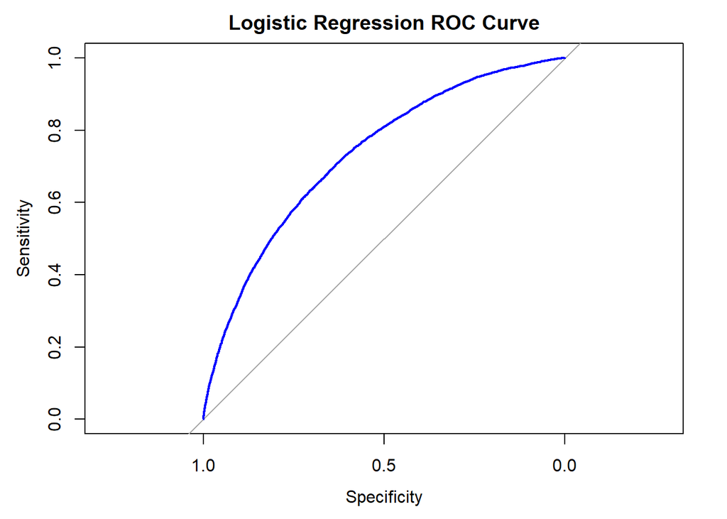

```r
#Predict downsampled without interactions on Test Data
logicPredunder <- predict(logicModelunder, appTest, type = 'response')

#Create ROC Curve
logicROCunder <- roc(appTest$TARGET, logicPredunder)
#Plot ROC Curve
plot(logicROCunder, col = 'blue', main = 'Logistic Regression ROC Curve')
```

```r
#Calculate AUC
auc(logicROCunder)
```

```
## Area under the curve: 0.732
```

```r
#Ensure numeric
logicPredunder <- as.numeric(logicPredunder)

#Threshold to predict
logicPredunder$predictor <- ifelse(logicPredunder > 0.5, "Yes", "No")
logicPredunder$predictor <- as.factor(logicPredunder$predictor)

#Confusion Matrix with percentages
confusionMatrix(logicPredunder$predictor, appTest$TARGET, positive = 'Yes')
```

```
## Confusion Matrix and Statistics
##
##           Reference
## Prediction    No   Yes
##        No  57856  2567
##        Yes 26948  4880
##
##                Accuracy : 0.6801
##                  95% CI : (0.677, 0.6831)
##     No Information Rate : 0.9193
##     P-Value [Acc > NIR] : 1
##
##                   Kappa : 0.1354
##
##  Mcnemar's Test P-Value : <2e-16
##
##             Sensitivity : 0.65530
##             Specificity : 0.68223
##          Pos Pred Value : 0.15332
##          Neg Pred Value : 0.95752
##              Prevalence : 0.08073
##          Detection Rate : 0.05290
##    Detection Prevalence : 0.34502
##       Balanced Accuracy : 0.66876
##
##        'Positive' Class : Yes
##
```

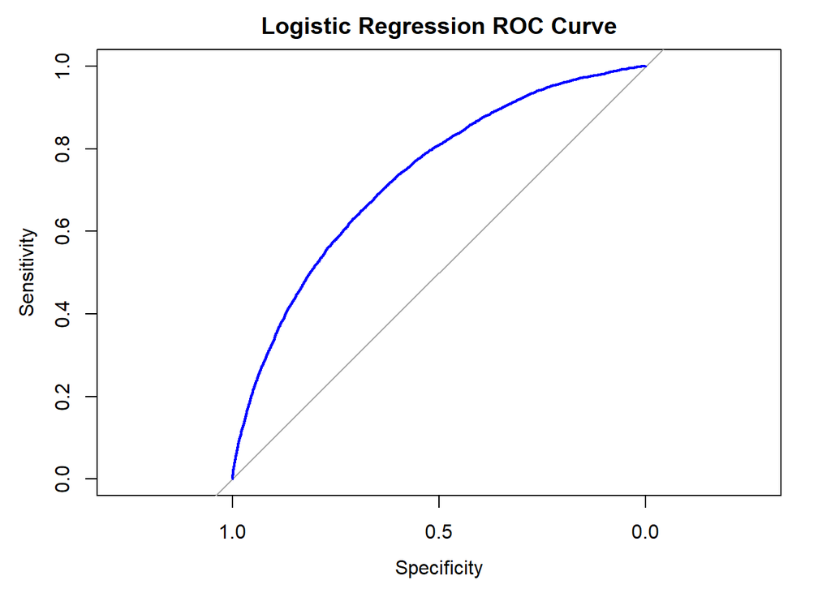

```r
#Original Logistic Model with no downsampling
logicPred <- predict(logitModel, appTest, type = 'response')


#Create ROC Curve
logicROC <- roc(appTest$TARGET, logicPred)
#Plot ROC Curve
plot(logicROC, col = 'blue', main = 'Logistic Regression ROC Curve')
```

```r
#Calculate AUC
auc(logicROC)
```

```
## Area under the curve: 0.7321
```

```r
#Ensure numeric
logicPred <- as.numeric(logicPred)

#Threshold to predict
logicPred$predictor <- ifelse(logicPred > 0.5, "Yes", "No")
logicPred$predictor <- as.factor(logicPred$predictor)

#Confusion Matrix with percentages
confusionMatrix(logicPred$predictor, appTest$TARGET, positive = 'Yes')
```

```
## Confusion Matrix and Statistics
##
##           Reference
## Prediction    No   Yes
##        No  84745  7411
##        Yes    59    36
##
##                Accuracy : 0.919
##                  95% CI : (0.9172, 0.9208)
##     No Information Rate : 0.9193
##     P-Value [Acc > NIR] : 0.6124
##
##                   Kappa : 0.0075
##
##  Mcnemar's Test P-Value : <2e-16
##
##             Sensitivity : 0.0048342
##             Specificity : 0.9993043
##          Pos Pred Value : 0.3789474
##          Neg Pred Value : 0.9195820
##              Prevalence : 0.0807254
##          Detection Rate : 0.0003902
##    Detection Prevalence : 0.0010298
##       Balanced Accuracy : 0.5020692
##
##        'Positive' Class : Yes
##
```

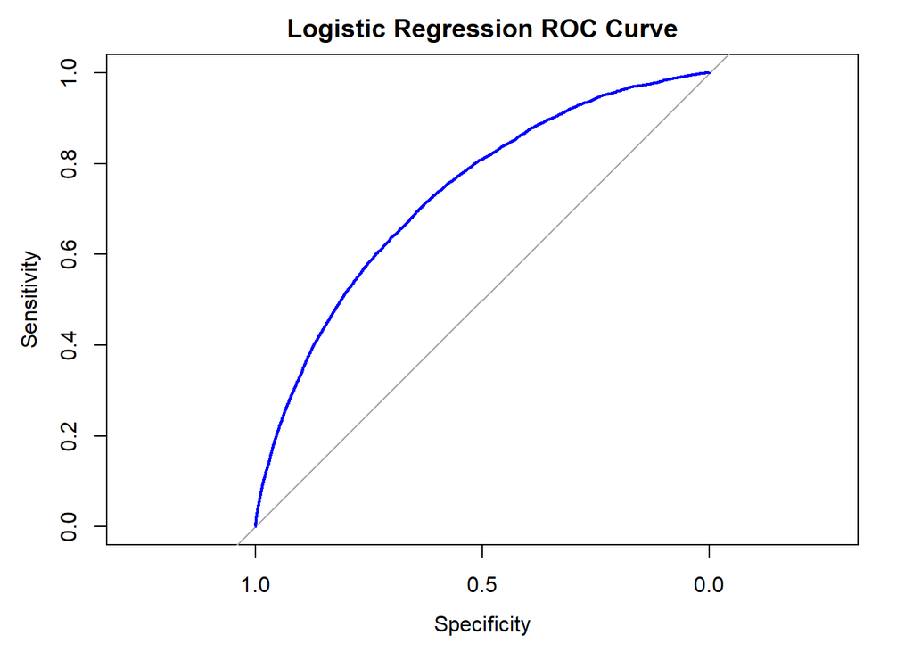

```r
#Upsample models
logicPredUp <- predict(logicModelover, appTest, type = 'response')

#Create ROC Curve
logicROCUp <- roc(appTest$TARGET, logicPredUp)
#Plot ROC Curve
plot(logicROCUp, col = 'blue', main = 'Logistic Regression ROC Curve')
```

```r
#Calculate AUC
auc(logicROCUp)
```

```
## Area under the curve: 0.732
```

```r
#Threshold to predict
logicPredUp$predictor <- ifelse(logicPredUp > 0.5, "Yes", "No")
logicPredUp$predictor <- as.factor(logicPredUp$predictor)

#Confusion Matrix with percentages
confusionMatrix(logicPredUp$predictor, appTest$TARGET, positive = 'Yes')
```

```
## Confusion Matrix and Statistics
##
##           Reference
## Prediction    No   Yes
##        No  57755  2565
##        Yes 27049  4882
##
##                Accuracy : 0.679
##                  95% CI : (0.676, 0.682)
##     No Information Rate : 0.9193
##     P-Value [Acc > NIR] : 1
##
##                   Kappa : 0.1347
##
##  Mcnemar's Test P-Value : <2e-16
##
##             Sensitivity : 0.65557
##             Specificity : 0.68104
##          Pos Pred Value : 0.15289
##          Neg Pred Value : 0.95748
##              Prevalence : 0.08073
##          Detection Rate : 0.05292
##    Detection Prevalence : 0.34613
##       Balanced Accuracy : 0.66830
##
##        'Positive' Class : Yes
##
```

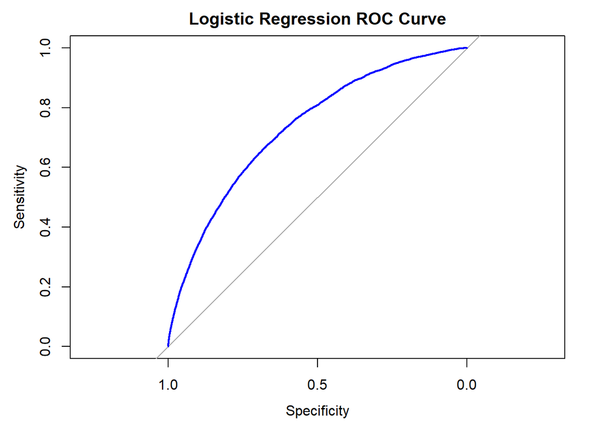

```r
#Upsample with interaction
logicPredUpInt <- predict(logicModeloverInt, appTest, type = 'response')

#Create ROC Curve
logicROCoverInt <- roc(appTest$TARGET, logicPredUpInt)
#Plot ROC Curve
plot(logicROCoverInt, col = 'blue', main = 'Logistic Regression ROC Curve')
```

```r
#Calculate AUC
auc(logicROCoverInt)
```

```
## Area under the curve: 0.7337
```

```r
#Threshold to predict
logicPredUpInt$predictor <- ifelse(logicPredUpInt > 0.5, "Yes", "No")
logicPredUpInt$predictor <- as.factor(logicPredUpInt$predictor)

#Confusion Matrix with percentages
confusionMatrix(logicPredUpInt$predictor, appTest$TARGET, positive = 'Yes')
```

```
## Confusion Matrix and Statistics
##
##           Reference
## Prediction    No   Yes
##        No  56846  2435
##        Yes 27958  5012
##
##                Accuracy : 0.6705
##                  95% CI : (0.6675, 0.6736)
##     No Information Rate : 0.9193
##     P-Value [Acc > NIR] : 1
##
##                   Kappa : 0.134
##
##  Mcnemar's Test P-Value : <2e-16
##
##             Sensitivity : 0.67302
##             Specificity : 0.67032
##          Pos Pred Value : 0.15202
##          Neg Pred Value : 0.95892
##              Prevalence : 0.08073
##          Detection Rate : 0.05433
##    Detection Prevalence : 0.35739
##       Balanced Accuracy : 0.67167
##
##        'Positive' Class : Yes
##
```

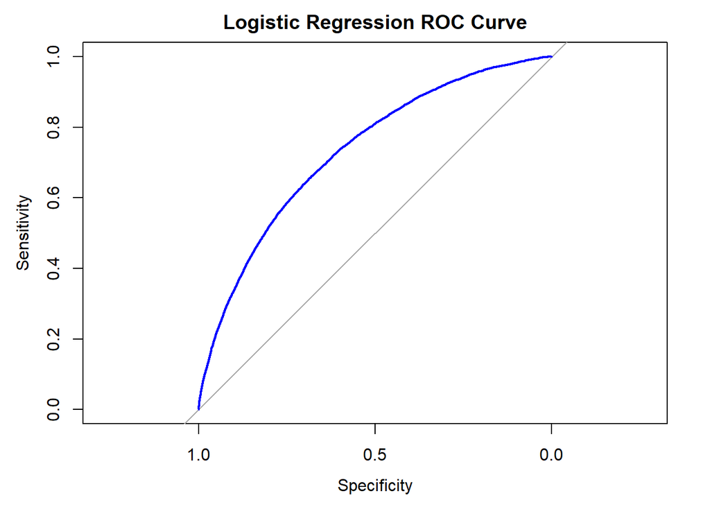

```r
#Upsampled with interaction and downsampled data
logicPredUpIntunderover <- predict(logicModelunderIntover, appTest, type = 'response')

#Create ROC Curve
logicROCoverIntunder <- roc(appTest$TARGET, logicPredUpIntunderover)
#Plot ROC Curve
plot(logicROCoverIntunder, col = 'blue', main = 'Logistic Regression ROC Curve')
```

```r
#Calculate AUC
auc(logicROCoverIntunder)
```

```
## Area under the curve: 0.7328
```

```r
#Threshold to predict
logicPredUpIntunderover$predictor <- ifelse(logicPredUpIntunderover > 0.5, "Yes", "No")
logicPredUpIntunderover$predictor <- as.factor(logicPredUpIntunderover$predictor)

#Confusion Matrix with percentages
confusionMatrix(logicPredUpIntunderover$predictor, appTest$TARGET, positive = 'Yes')
```

```
## Confusion Matrix and Statistics
##
##           Reference
## Prediction    No   Yes
##        No  57408  2506
##        Yes 27396  4941
##
##                Accuracy : 0.6759
##                  95% CI : (0.6728, 0.6789)
##     No Information Rate : 0.9193
##     P-Value [Acc > NIR] : 1
##
##                   Kappa : 0.1349
##
##  Mcnemar's Test P-Value : <2e-16
##
##             Sensitivity : 0.66349
##             Specificity : 0.67695
##          Pos Pred Value : 0.15280
##          Neg Pred Value : 0.95817
##              Prevalence : 0.08073
##          Detection Rate : 0.05356
##    Detection Prevalence : 0.35053
##       Balanced Accuracy : 0.67022
##
##        'Positive' Class : Yes
##
```

The base logistic model with 8 important predictors has a very low sensitivity (0.48%), which means it’s not effective at identifying loan defaults, likely due to the imbalance of data. The oversampled logistic models, both exhibit similar performance characteristics. oversampling w/o interaction has a sensitivity of 65.6% and a precision of 15.3%, while oversampling w/interaction has a sensitivity of 67.3% and a precision of 15.2%. These low precision values indicate a significant number of false positives, meaning that cases are predicted as defaults that do not actually default. In the context of lending, where the goal is to minimize the risk of lending to clients who will default, a high precision model may be preferred, however a high sensitivity may also be important to capture as many actual defaults as possible ensuring as much money can reliable be lent out as possible to those who won’t default.

The logistic model with interactions has an AUC of 0.7326, with the under sampled version having an AUC of 0.7320 and the base 8 important var model with an AUC of 0.7321. The upsampling model without interaction had an AUC of 0.7320 while the oversampled model with interactions had an AUC of 0.7337. The upsampled with interaction and downsampled data jad am AIC of 0.7328.

# Other Models Considered

## Model 2

Another model that we considered using was a Random Forest model. This model ultimately processed very good results that were very competitive with our preferred Logistic Regression Model, but for the reasons mentioned above around visibility and transparency into how the model is making predictions we decided against using it as our preferred model.

### Data Preparation

```r
#read in test data
clean_test <- read_csv('clean_test.csv') %>%
  mutate_if(is.character, as.factor)
 # Initialize all values to 0 as factors
clean_test$TARGET <- factor(0)

#Add TARGET as a factor to new column TARGET
clean_test$TARGET <- factor(clean_test$TARGET,
                              levels = c(0, 1), labels = c(0, 1))

#Read in Train Data
clean_train <- read.csv(file = "clean_train.csv", stringsAsFactors = TRUE)
summary(clean_train)
```

```
##      TARGET              NAME_CONTRACT_TYPE CODE_GENDER FLAG_OWN_CAR
##  Min.   :0.00000   Cash loans     :278232   F:202448    N:202922
##  1st Qu.:0.00000   Revolving loans: 29275   M:105059    Y:104585
##  Median :0.00000
##  Mean   :0.08073
##  3rd Qu.:0.00000
##  Max.   :1.00000
##
##  FLAG_OWN_REALTY             NAME_INCOME_TYPE
##  N: 94199        Working             :158771
##  Y:213308        Commercial associate: 71616
##                  Pensioner           : 55362
##                  State servant       : 21703
##                  Unemployed          :    22
##                  Student             :    18
##                  (Other)             :    15
##                     NAME_EDUCATION_TYPE   DAYS_BIRTH    DAYS_EMPLOYED
##  Academic degree              :   164   Min.   : 7489   Min.   :    0
##  Higher education             : 74862   1st Qu.:12413   1st Qu.:  933
##  Incomplete higher            : 10276   Median :15750   Median : 1648
##  Lower secondary              :  3816   Mean   :16037   Mean   : 2252
##  Secondary / secondary special:218389   3rd Qu.:19682   3rd Qu.: 2760
##                                         Max.   :25229   Max.   :17912
##
##  DAYS_REGISTRATION DAYS_ID_PUBLISH FLAG_WORK_PHONE    FLAG_PHONE
##  Min.   :    0     Min.   :   0    Min.   :0.0000   Min.   :0.0000
##  1st Qu.: 2010     1st Qu.:1720    1st Qu.:0.0000   1st Qu.:0.0000
##  Median : 4504     Median :3254    Median :0.0000   Median :0.0000
##  Mean   : 4986     Mean   :2994    Mean   :0.1994   Mean   :0.2811
##  3rd Qu.: 7480     3rd Qu.:4299    3rd Qu.:0.0000   3rd Qu.:1.0000
##  Max.   :24672     Max.   :7197    Max.   :1.0000   Max.   :1.0000
##
##    FLAG_EMAIL      CNT_FAM_MEMBERS  REGION_RATING_CLIENT_W_CITY
##  Min.   :0.00000   Min.   : 1.000   Min.   :1.000
##  1st Qu.:0.00000   1st Qu.: 2.000   1st Qu.:2.000
##  Median :0.00000   Median : 2.000   Median :2.000
##  Mean   :0.05672   Mean   : 2.153   Mean   :2.032
##  3rd Qu.:0.00000   3rd Qu.: 3.000   3rd Qu.:2.000
##  Max.   :1.00000   Max.   :20.000   Max.   :3.000
##
```

[output cut: 9 more lines]

```
##  Min.   :0.0000001   Min.   :0.0005273   Min.   :0.00    Min.   :10.15
##  1st Qu.:0.3929737   1st Qu.:0.4170997   1st Qu.:0.00    1st Qu.:11.63
##  Median :0.5659614   Median :0.5352763   Median :1.00    Median :11.90
##  Mean   :0.5145025   Mean   :0.5156977   Mean   :0.71    Mean   :11.91
##  3rd Qu.:0.6634218   3rd Qu.:0.6363762   3rd Qu.:1.00    3rd Qu.:12.22
##  Max.   :0.8549997   Max.   :0.8960095   Max.   :1.00    Max.   :18.58
##
##  log_AMT_CREDIT
##  Min.   :10.71
##  1st Qu.:12.51
##  Median :13.15
##  Mean   :13.07
##  3rd Qu.:13.60
##  Max.   :15.21
##
```

```r
#Factor TARGET
clean_train$TARGET <- factor(clean_train$TARGET,
                             levels = c(0, 1), labels = c('No', 'Yes'))
```

When reading in the data, the target variable was converted into a factor